# Does length increase prices in diamonds?

```r
t.test(d1$price, d2$price, alternative = "two.sided", var.equal = FALSE)
```

```
##
##  Welch Two Sample t-test
##
## data:  d1$price and d2$price
## t = 223.21, df = 27533, p-value < 2.2e-16
## alternative hypothesis: true difference in means is not equal to 0
## 95 percent confidence interval:
##  5581.940 5680.843
## sample estimates:
## mean of x mean of y
##  6852.479  1221.087
```

## Hypothesis Test Output

Using a Welch two sample t-test:

$h_o: \mu_{d1} = \mu_{d2} \\ h_a: \mu_{d1} \neq \mu_{d2}$

From this test, with test statistic 223.21 and p-value < .001, we reject the null hypothesis. Thus, we conclude that diamonds with less than average length ($x < 5.731mm$) and diamonds with greater than or equal to average length ($x \geq 5.731mm$) do not have the same average price.

## Singular Linear Regression Output

Next, let’s move on to what effect the size actually has, using a linear model. We’ll be using the whole diamonds set and observe what the variable x - the length of the diamond - has on the price.

```r
model1 <- lm(price ~ x , data = diamonds)
summary(model1)
```

```
##
## Call:
## lm(formula = price ~ x, data = diamonds)
##
## Residuals:
##    Min     1Q Median     3Q    Max
##  -8426  -1264   -185    973  32128
##
## Coefficients:
##               Estimate Std. Error t value Pr(>|t|)
## (Intercept) -14094.056     41.732  -337.7   <2e-16 ***
## x             3145.413      7.146   440.2   <2e-16 ***
## ---
## Signif. codes:  0 '***' 0.001 '**' 0.01 '*' 0.05 '.' 0.1 ' ' 1
##
## Residual standard error: 1862 on 53938 degrees of freedom
## Multiple R-squared:  0.7822, Adjusted R-squared:  0.7822
## F-statistic: 1.937e+05 on 1 and 53938 DF,  p-value: < 2.2e-16
```

We see that, based on our output, the coefficient on x, our length, is positive, which answers the question of “does length increase price?” Yes, it does. Since our coefficient is positive, we know that for each unit increase, our dependent variable will increase: contextually and in Layman’s, for each mm increase of length on a diamond, the price of it goes up by about $3145. Jumping a little further into the output, we see that the p-value ($2e^{-16}$) on our coefficient and variable is very small, falling into every standard significance level. This is also the same p-value from our earlier hypothesis test. Again, simply, we can see here that the length of a diamond changes the price by about $3145 per additional mm. The keen will notice that for appropriately small diamonds, they apparently sell for a negative price - unfortunately, they do not. So, why does our regression tell us this? We need to center our diamond price variable around the mean, so that a diamond with average length has an average price. Lastly, this’ll pop up later, but we have an R-Squared of .78, meaning that approximately 78% of the variability is accounted for, or rather than our model is not a perfect predictor, or even further, that we do cannot predict the price of a diamond accurately without more information of a different variable.

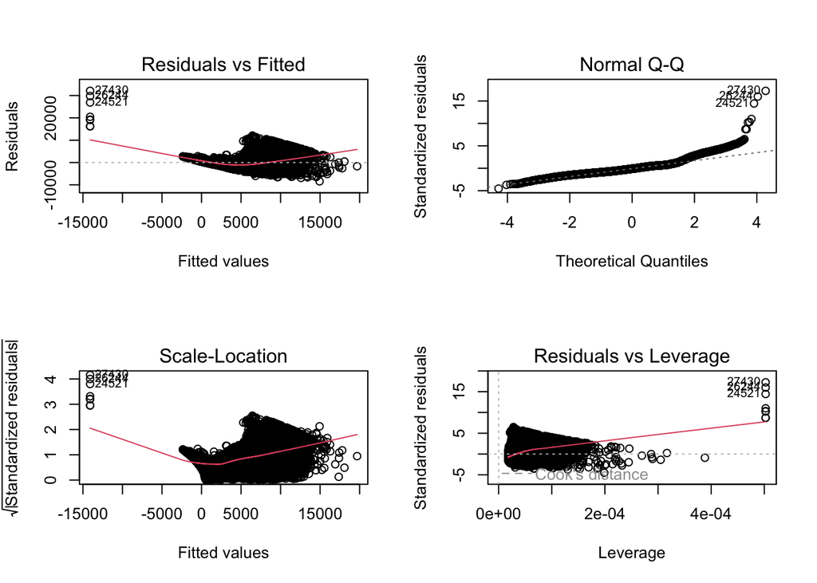

```r
par(mfrow=c(2,2))
plot(model1)
```

Technically, we are supposed to look look at these plots, which validate (or invalidate in our case) our assumptions. Since we already know that our model isn’t well made, I won’t harp on this too much. In the two leftmost graphs, the red line (and the data accompanying it) should have no correlation, or basically have the red line be straight and the data should just be around it without any pattern. These are ‘passable’ results, in the way that it is good enough for me to interpret rather than fix. On the Normal Q-Q plot, we should see that all of our points follow that dotted line (that we can’t see too much of), but normally we allow for a little drifting at the ends. In our Normal Q-Q, I think there’s a little too much drifting, but again neither here nor there. Lastly, on the residuals vs leverage, we’re actually doing pretty well. Usually, there’s a dotted red line that shows if there are outliers in our set, and since we cannot see a line, we are not even close to having any outliers. Overall, if I had to rate the model off of just these plots, I’d say the model is a 6/10. Not great, but good enough to interpret.